# Survival Analysis part 2

03/21/2018

## Cox-PH Regression

## Physicians Health Study and Aspirin

Recall the Colorectal Cancer component of the Physicians Health Study

| Name | Description |
| --- | --- |
| age | Age in years at time of Randomization |
| asa | 0 - placebo, 1 - aspirin |
| bmi | Body Mass Index (kg/\(m^2\)) |
| hypert | 1 - Hypertensive at baseline, 0 - Not |
| alcohol | 0 - less than monthly, 1 - monthly to less than daily, 2 - daily consumption |

| Name | Description |
| --- | --- |
| dm | 0 = No diabetes Mellitus, 1 - diabetes Mellitus |
| sbp | Systolic BP (mmHg) |
| exer | 0 - No regular, 1 - Sweat at least once per week |
| csmoke | 0 - Not currently, 1 - < 1 pack per day, 2 - \(\ge\) 1 pack per day |
| psmoke | 0 - never smoked, 1 - former < 1 pack per day, 2 - former \(\ge\) 1 pack per day |
| pkyrs | Total lifetime packs of cigarettes smoked |
| crc | 0 - No colorectal Cancer, 1 - Colorectal cancer |
| cayrs | Years to colorectal cancer, or death, or end of follow-up. |

For this study each participant contributed 2 pieces of information during follow-up:

1. Information on whether of not they had a Colorectal Cancer(CRC) during follow-up
2. Follow-up time in years, specified as time from randomization until first of
   - end of Study
   - death
   - Colorectal Cancer
   - Loss to follow-up

We can load this data into R.

```r
library(tidyverse)
library(haven)
phscrc <- read_dta("phscrc.dta")
phscrc <- phscrc %>% mutate(age.cat = cut(age, c(40, 50, 60,
    70, 90), right = FALSE)) %>% mutate(alcohol.use = factor(alcohol >
    1, labels = c("no", "yes"))) %>% mutate(obese = factor(bmi >
    30, labels = c("Not Obese", "Obese")))
```

## Proportional Hazards Model

The general *Proportional Hazards Model* is \[h(t|X_1,\ldots, X_p) = h_0(t)\exp\left(\beta_1x_1 + \cdots + \beta_px_p\right)\]

\[\text{or}\]

\[\log\left[h(t|X_1,\ldots, X_p)\right] = \log\left[h_0(t)\right] + \beta_1x_1 + \cdots + \beta_px_p\]

where \(h_0(t)\) is the baseline hazard function and the "intercept" is \(\log\left[h_0(t)\right]\).

## Semi-Parametric Regression

- Weibull and Exponential are examples of parametric proportional hazards models, where \(h_0(t)\) is a specified function.
- In 1972, Cox generalized these types of models so that we can make inferences on the \(\beta_1, \ldots,\beta_p\) without specifying \(h_0(t)\).
- We call Cox a semi-parametric regression model
- We fit this using something called *Partial Likelihood Estimation*
- Once again we use an algorithm to maximize the partial likelihood.

## Interpeting the Model

Let

- \(X=0\) be the control group
- \(X=1\) be the treatment group

Then

\[\begin{aligned} h(t|X=x) &= h_0(t)\exp(\beta x)\\ h(t|X=0) &= h_0(t)\\ &= \text{ baseline hazard for control group}\\ h(t|X=1) &= h_0(t)\exp(\beta)\\ &= \text{ hazard for treated group}\\ \exp(\beta) &= \dfrac{h(t|X=1)}{h(t|X=0)}\\ \end{aligned}\]

## What Does This Mean?

- This means that the hazard ratio is constant over time (**Proportional Hazards**)
- \(\beta\) is the log hazard ratio or log-relative risk
- According to the Cox model

\[\begin{aligned} \log\left[h]h(t|X=0)\right] &= \log\left[h_0(t)\right]\\ \log\left[h]h(t|X=1)\right] &= \log\left[h_0(t)\right] + \beta\\ \end{aligned}\]

- This means the log of the hazard functions are parallel over time.
- We make no assumptions about \(h_0(t)\).

## Verifying Proportional Hazards Assumption

Recall \[S(t) = \exp\left(-\Lambda(t)\right)\] with a binary \(X\) we have that

\[\begin{aligned} \Lambda_1(t) &= \Lambda_0(t)\exp(\beta)\\ S_0(t) &= \exp(\Lambda_0(t))\\ -\log(S_0(t)) &= \Lambda_0(t)\\ \log(-\log(S_0(t))) &=\log(\Lambda_0(t))\\ \end{aligned}\] \[\begin{aligned} S_1(t) = exp(-\Lambda_1(t)) &= \exp\left[\Lambda_0(t)\exp(\beta)\right]\\ -\log(S_1(t)) &= \Lambda_0(t)\exp(\beta)\\ \log(-\log(S_1(t))) &= \log(\Lambda_0(t)) + \beta\\ \end{aligned}\]

## Verifying Proportional Hazards Assumption

- Thus we can see that under the assumption of *proportional hazards*
  - \(\log(-\log(K-M))\) should be parallel over time.
  - We typically verify this graphically.
  - Recall the CRC study:

## Example: Kaplan-Meier Survival

```r
library(survival)

model <- survfit(Surv(cayrs, crc) ~ alcohol.use, data = subset(phscrc,
    cayrs > 0))
model
```

## Example: Kaplan-Meier Survival

```
## Call: survfit(formula = Surv(cayrs, crc) ~ alcohol.use, data = subset(phscrc,
##     cayrs > 0))
##
##                     n events median 0.95LCL 0.95UCL
## alcohol.use=no  12162    173     NA      NA      NA
## alcohol.use=yes  3856     81     NA      NA      NA
```

## Plotting the Kaplan-Meier

```r
library(survminer)
ggsurvplot(model, legend.labs = c("Non-Drinker", "Drinker"),
    break.time.by = 2, fun = "cloglog")
```

## Plotting the Kaplan-Meier

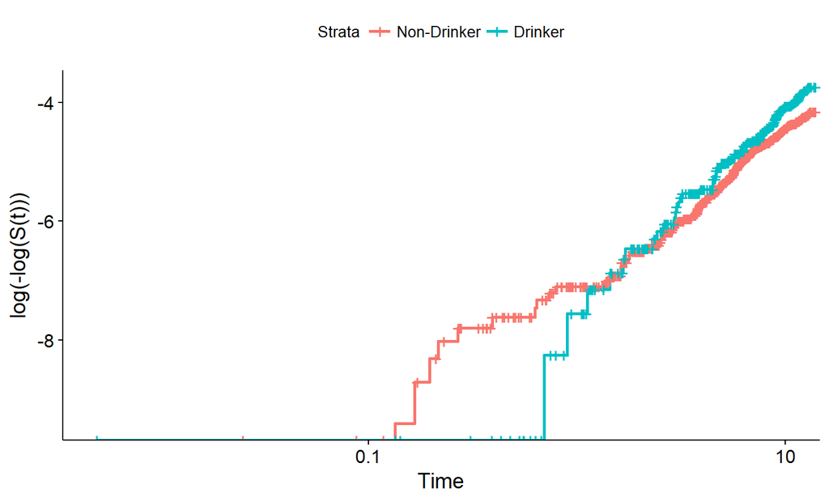

## Cox PH in R

- We can run the Cox PH in R:

```r
cox.crc <- coxph(Surv(cayrs, crc) ~ alcohol.use, data = subset(phscrc,
    cayrs > 0))
summary(cox.crc)
```

## Cox PH in R

```
## Call:
## coxph(formula = Surv(cayrs, crc) ~ alcohol.use, data = subset(phscrc,
##     cayrs > 0))
##
##   n= 16018, number of events= 254
##
##                 coef exp(coef) se(coef)    z Pr(>|z|)
## alcohol.useyes 0.414     1.514    0.135 3.08   0.0021 **
## ---
## Signif. codes:  0 '***' 0.001 '**' 0.01 '*' 0.05 '.' 0.1 ' ' 1
##
##                exp(coef) exp(-coef) lower .95 upper .95
## alcohol.useyes      1.51      0.661      1.16      1.97
##
## Concordance= 0.541  (se = 0.013 )
## Rsquare= 0.001   (max possible= 0.262 )
## Likelihood ratio test= 8.97  on 1 df,   p=0.00275
## Wald test            = 9.48  on 1 df,   p=0.00208
## Score (logrank) test = 9.61  on 1 df,   p=0.00193
```

## Interpretation

- This would suggest that the hazard of Colorectal Cancer for those who drink daily is 51% higher than those who drink less than daily.

## Continuous Example of Cox PH

- Let's consider `age` and `smoking`:

```r
library(survival)
crc.cox <- coxph(Surv(cayrs, crc) ~ csmok + age, data = subset(phscrc,
    cayrs > 0))
summary(crc.cox)
```

## Continuous Example of Cox PH

```
## Call:
## coxph(formula = Surv(cayrs, crc) ~ csmok + age, data = subset(phscrc,
##     cayrs > 0))
##
##   n= 16018, number of events= 254
##
##          coef exp(coef) se(coef)     z Pr(>|z|)
## csmok 0.31715   1.37320  0.09767  3.25   0.0012 **
## age   0.07904   1.08224  0.00628 12.58   <2e-16 ***
## ---
## Signif. codes:  0 '***' 0.001 '**' 0.01 '*' 0.05 '.' 0.1 ' ' 1
##
##       exp(coef) exp(-coef) lower .95 upper .95
## csmok      1.37      0.728      1.13      1.66
## age        1.08      0.924      1.07      1.10
##
## Concordance= 0.724  (se = 0.018 )
## Rsquare= 0.01   (max possible= 0.262 )
## Likelihood ratio test= 160  on 2 df,   p=0
## Wald test            = 163  on 2 df,   p=0
## Score (logrank) test = 177  on 2 df,   p=0
```

## Interpretation

- Then we could say that for two people with the same smoking status a one year increase in age would lead to an 8.2% increase in the hazard of colorectal cancer with a 95% CI of 6.9% to 9.6%.
- We would also be able to say that for 2 people the same age, a person who is a current smoker would have a 37% increase in hazard of colorectal cancer than a non smoker.

## Cox-PH Regression

## Assessing Diagnostics and Model Fit with Cox-PH

- With the Cox PH model we will consider 2 things
  - Checking Proportional Hazards Assumption
  - Checking for Influential Observations

## Variables

| Variable | Description |
| --- | --- |
| week | week of first arrest after release, or censoring time. |
| arrest | the event indicator, equal to 1 for those arrested during the period of the study and 0 for those who were not arrested. |
| fin | a factor, with levels yes if the individual received financial aid after release from prison, and no if he did not; financial aid was a randomly assigned factor manipulated by the researchers. |

## Variables

| Variable | Description |
| --- | --- |
| age | in years at the time of release. |
| wexp | a factor with levels yes if the individual had full-time work experience prior to incarceration and no if he did not. |
| mar | a factor with levels married if the individual was married at the time of release and not married if he was not. |
| paro | a factor coded yes if the individual was released on parole and no if he was not. |
| prior | number of prior convictions. |

## Variables

| Variable | Description |
| --- | --- |
| educ | education, a categorical variable coded numerically, with codes 2 (grade 6 or less), 3 (grades 6 through 9), 4 (grades 10 and 11), 5 (grade 12), or 6 (some post-secondary).6 |
| emp1 – emp52 | factors coded yes if the individual was employed in the corresponding week of the study and no otherwise. |
| race | a factor with levels black and other. |

## Reading Data in

```r
url <- "http://socserv.mcmaster.ca/jfox/Books/Companion/data/Rossi.txt"
Rossi <- read.table(url, header = TRUE)
```

## Our Model

```r
library(survival)
library(tidyverse)
library(broom)
mod1 <- coxph(Surv(week, arrest) ~ fin + age + race + wexp +
    mar + paro + prio, data = Rossi)
tidy1 <- tidy(mod1, exponentiate = T)
knitr::kable(tidy1[-c(3, 4)])
```

## Our Model

| term | estimate | p.value | conf.low | conf.high |
| --- | --- | --- | --- | --- |
| finyes | 0.684 | 0.047 | 0.470 | 0.996 |
| age | 0.944 | 0.009 | 0.904 | 0.986 |
| raceother | 0.731 | 0.308 | 0.399 | 1.336 |
| wexpyes | 0.861 | 0.480 | 0.568 | 1.305 |
| marnot married | 1.543 | 0.256 | 0.730 | 3.261 |
| paroyes | 0.919 | 0.665 | 0.626 | 1.348 |
| prio | 1.096 | 0.001 | 1.036 | 1.159 |

## Plotting Regression

```r
library(ggplot2)
library(ggfortify)
autoplot(survfit(mod1), surv.linetype = "dashed", surv.colour = "blue",
    conf.int.fill = "dodgerblue3", conf.int.alpha = 0.5, censor = FALSE)
```

## Plotting Regression

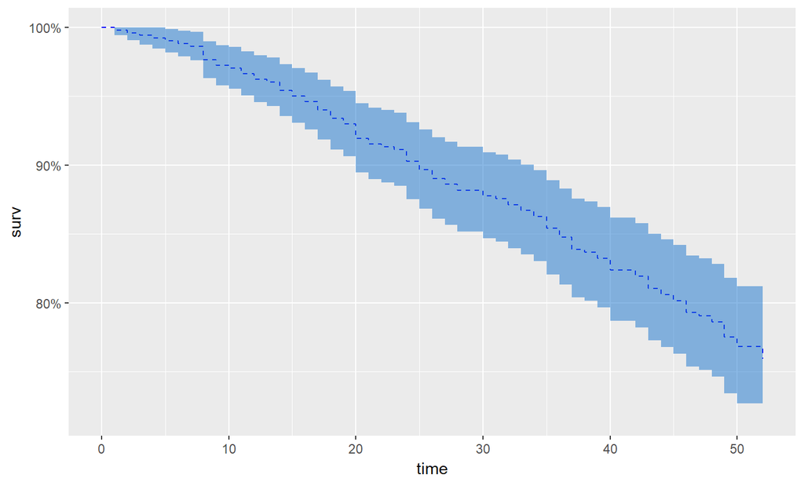

## Checking Proportional Hazards

- We have tested these before with Schoenfeld Residuals
- We can do this with the `cox.zph()` function.

## Checking Proportional Hazards

```r
cox.zph(mod1)
```

```
##                     rho    chisq        p
## finyes          0.00646  0.00502 0.943519
## age            -0.26455 11.27897 0.000784
## raceother       0.11224  1.41652 0.233977
## wexpyes         0.22976  7.14021 0.007537
## marnot married -0.07295  0.68627 0.407435
## paroyes        -0.03618  0.15496 0.693841
## prio           -0.01366  0.02304 0.879353
## GLOBAL               NA 17.65862 0.013609
```

## Conclusion

- We see there is an issue
  - `age` is an issue
  - `wexp` is an issue as well.
- What do we do???

## Enter Stratification

- We can adjust for a variable that does not meet the proportional hazards assumption by stratification.
- Assume we have \(Z\) which does not allow for PH \[h(t|X, Z=j) = h_j(t)exp(X\beta)\]
- \(j=1,ldots,C\) levels of Z.

## Create Age Categories

```r
Rossi$age.cat <- cut(Rossi$age, c(0, 19, 25, 30, Inf))
xtabs(~age.cat, data = Rossi)
```

```
## age.cat
##   (0,19]  (19,25]  (25,30] (30,Inf]
##       66      236       66       64
```

## Re Run the Model

```r
mod2 <- coxph(Surv(week, arrest) ~ fin + race + mar + paro +
    prio + strata(wexp, age.cat), data = Rossi)
tidy2 <- tidy(mod2, exponentiate = T)
knitr::kable(tidy2[-c(3, 4)])
```

| term | estimate | p.value | conf.low | conf.high |
| --- | --- | --- | --- | --- |
| finyes | 0.675 | 0.040 | 0.463 | 0.983 |
| raceother | 0.720 | 0.290 | 0.392 | 1.322 |
| marnot married | 1.462 | 0.326 | 0.686 | 3.117 |
| paroyes | 0.915 | 0.650 | 0.623 | 1.343 |
| prio | 1.084 | 0.004 | 1.026 | 1.146 |

## PH Assumption

```r
cox.zph(mod2)
```

```
##                    rho  chisq     p
## finyes         -0.0147 0.0252 0.874
## raceother       0.1086 1.3066 0.253
## marnot married -0.0794 0.8033 0.370
## paroyes        -0.0112 0.0141 0.906
## prio           -0.0174 0.0326 0.857
## GLOBAL              NA 2.3420 0.800
```

## Influential Observations

- to test this let's build a smaller model

```r
mod3 <- coxph(Surv(week, arrest) ~ fin + prio + strata(age.cat),
    data = Rossi)
```

## Influential Observations

- With Cox PH we will use DFBETA to tell.
- DFBETA's measure how much an observation has effected the estimated coefficient.
- We look for values to be under \(\dfrac{2}{\sqrt{n}}\).

## DFBETA in R

```r
library(survminer)
2/sqrt(dim(Rossi)[1])
```

```
## [1] 0.0962
```

```r
ggcoxdiagnostics(mod3, type = "dfbeta", linear.predictions = FALSE,
    ggtheme = theme_bw())
```

## DFBETA in R

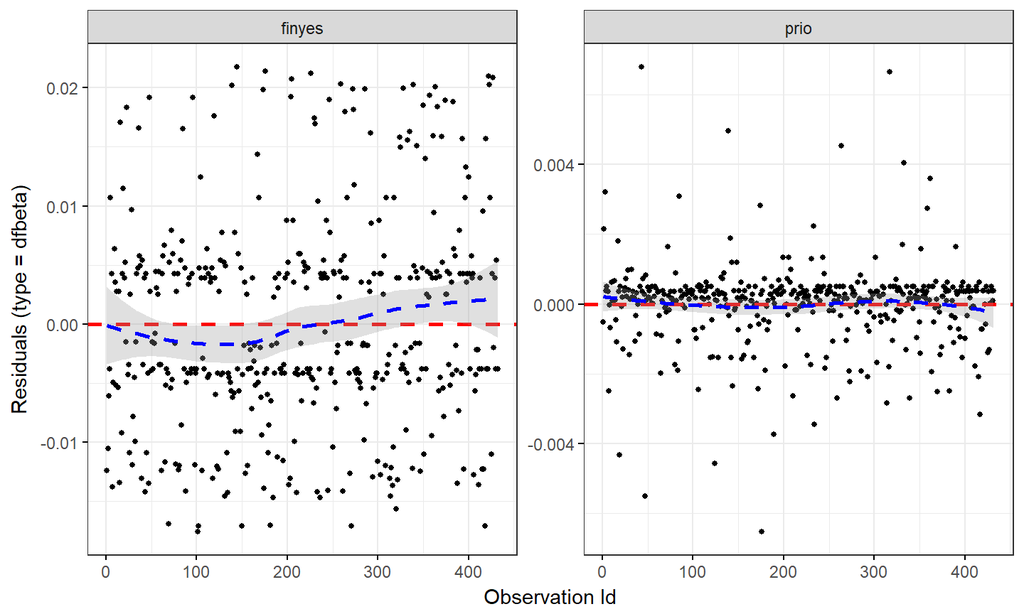